# ¿Dónde están y cuánto tardan las plazas IT municipales?

Radiografía de 814 procesos selectivos en el entorno de Vic (45 km) · Presentación ejecutiva (5 min)

Proyecto EDA — Oposicions CIDO

2026-11-04

## El reto: separar el mito del dato real

Quien busca o planifica empleo público de informática en la administración local suele asumir dos cosas:

1. *“Las oposiciones tardan años en resolverse.”*
2. *“Las oportunidades reales solo están en las grandes ciudades.”*

Analizamos **todos los registros públicos del CIDO (Diputació de Barcelona)** en un radio de **45 km desde Vic** (2004–2026):

- **814 procesos selectivos** de informática y nuevas tecnologías.
- **2.690 hitos oficiales** (BOPB / DOGC) limpios y auditados.
- **Cero datos personales** (diseño RGPD: solo metadatos de las plazas, nunca de aspirantes).

## El hallazgo principal

> **Los municipios pequeños e intermedios convocan más plazas IT por habitante y las resuelven en ~4 meses (frente a >7 meses en los grandes municipios).**

### Velocidad real

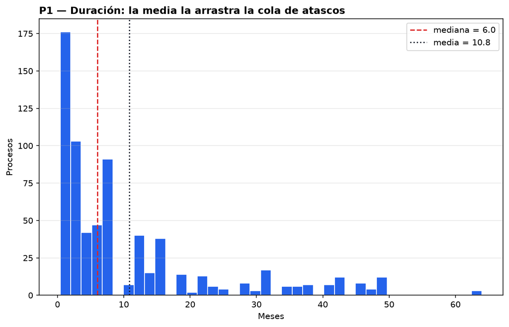